# Testing out Seurat

Haskan Kaya

Weds 22nd April 2020

### Introduction

Seurat seems to be the most popular package for scRNA-seq analysis, so I thought I should try it out. I don’t like R, so I’m not sure it’s what I want to use long term, but I feel like I should learn to use it so that a) I understand other people’s analyses and b) if I need to get analyses done quickly, I have an option that I know works.

This is me going through the Seurat tutorial which can be found at https://satijalab.org/seurat/v3.1/pbmc3k_tutorial.html .

### Loading things in

First, Load in the packages required. Then, load in the dataset and initialise the Seurat object it with raw data. This raw data comes from the output of the cellranger pipeline from 10X, which is a UMI count matrix. Each row is a feature (gene) and each column is a cell. The Seurat object which I create contains both the data and the analysis results (like PCA or clustering results) for one dataset.

```r
library(dplyr)
library(Seurat)
library(patchwork)
```

```r
path_to_data <- "/Users/kayah/OneDrive - The Francis Crick Institute/Code/seurat-tutorial/filtered_gene_bc_matrices/hg19"

#load in the PBMC data
pbmc.data <- Read10X(path_to_data)

#initialize the Seurat object with the raw (non-normalised data)
pbmc <- CreateSeuratObject(counts = pbmc.data, project = "pbmc3k", min.cells = 3, min.features = 200)
```

```
Feature names cannot have underscores ('_'), replacing with dashes ('-')
```

```r
pbmc
```

```
An object of class Seurat
13714 features across 2700 samples within 1 assay
Active assay: RNA (13714 features, 0 variable features)
```

#### Let’s take a look at what the data in the count matrix actually looks like…

```r
pbmc.data[c("CD3D", "TCL1A", "MS4A1"), 1:30]
```

```
3 x 30 sparse Matrix of class "dgCMatrix"
```

```
   [[ suppressing 30 column names ‘AAACATACAACCAC-1’, ‘AAACATTGAGCTAC-1’, ‘AAACATTGATCAGC-1’ ... ]]
```

```
CD3D  4 . 10 . . 1 2 3 1 . . 2 7 1 . . 1 3 . 2  3 . . . . . 3 4 1 5
TCL1A . .  . . . . . . 1 . . . . . . . . . . .  . 1 . . . . . . . .
MS4A1 . 6  . . . . . . 1 1 1 . . . . . . . . . 36 1 2 . . 2 . . . .
```

### Preprocessing

The selection and filtering of cells based on QC metrics, data normalisation, and scaling. It also includes detection of highly variable features.

Some features which are used for quality control include: - the number of unique genes found in each cell (low quality cells have very few, and cell doublets/multiplets have very high) - the total number of molecules found in a cell (correlates strongly with unique genes) - the percentage of reads that map to the mitochondrial genome (dying cells have extensive numbers of mitochondrial contamination…)

```r
#Some of these data are already found within the object. I need to add the mitochondrial percentage, though
#The [[ operator allows you to add a column to an object's metadata. This is good for storing QC information. In this example I am storing the percentage of the counts that map to the mitochondria.
pbmc[["percent.mt"]] <- PercentageFeatureSet(pbmc, pattern = "^MT-")
```

First, let’s visualise the distributions of these measures to understand where we should set our filters…

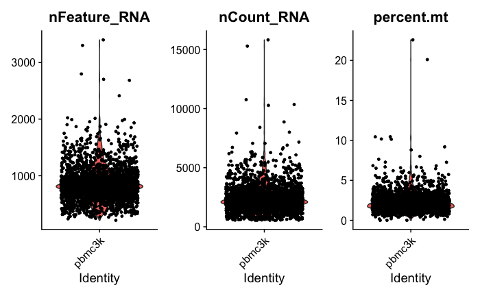

```r
VlnPlot(pbmc, features = c("nFeature_RNA", "nCount_RNA", "percent.mt"), ncol = 3)
```

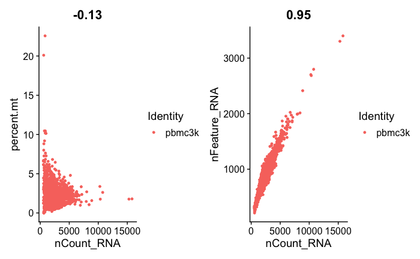

```r
#and now some scatter plots looking at the metadata against each other - really just to understand the relationship, I think...
plot1 <- FeatureScatter(pbmc, feature1 = "nCount_RNA", feature2 = "percent.mt")
plot2 <- FeatureScatter(pbmc, feature1 = "nCount_RNA", feature2 = "nFeature_RNA")

#This is using the patchwork library:
plot1 + plot2
```

Now, lets filter the data based on looking at these graphs. I am following the filtering criteria from the tutorial and I understand why they pick 5% mt transcripts, and I understand why they do nFeature_RNA at <2500 - but I’m not sure how they picked the nFeature_RNA at over 200 tbh. You can’t really see that in these visualisations.

```r
pbmc <- subset(pbmc, subset = nFeature_RNA > 200 & nFeature_RNA < 2500 & percent.mt < 5)
```